# Biostat 203B Homework 5

Due Mar 22 @ 11:59PM

Author

Feiyang Huang, UID 306148942

## Predicting ICU duration

Using the ICU cohort `mimiciv_icu_cohort.rds` you built in Homework 4, develop at least three machine learning approaches (logistic regression with enet regularization, random forest, boosting, SVM, MLP, etc) plus a model stacking approach for predicting whether a patient’s ICU stay will be longer than 2 days. You should use the `los_long` variable as the outcome. You algorithms can use patient demographic information (gender, age at ICU `intime`, marital status, race), ICU admission information (first care unit), the last lab measurements before the ICU stay, and first vital measurements during ICU stay as features. You are welcome to use any feature engineering techniques you think are appropriate; but make sure to not use features that are not available at an ICU stay’s `intime`. For instance, `last_careunit` cannot be used in your algorithms.

1. Data preprocessing and feature engineering.
2. Partition data into 50% training set and 50% test set. Stratify partitioning according to `los_long`. For grading purpose, sort the data by `subject_id`, `hadm_id`, and `stay_id` and use the seed `203` for the initial data split. Below is the sample code.
3. Train and tune the models using the training set.
4. Compare model classification performance on the test set. Report both the area under ROC curve and accuracy for each machine learning algorithm and the model stacking. Interpret the results. What are the most important features in predicting long ICU stays? How do the models compare in terms of performance and interpretability?

**Answer Part:**

Necessary packages:

```r
library(dplyr)
library(tidymodels)
library(GGally)
library(gtsummary)
library(tidyverse)
library(ranger)
library(kernlab)
library(keras)
library(xgboost)
library(stacks)
library(vip)
```

Read data:

```r
mimic_icu_cohort <- readRDS("~/mimiciv_shiny/mimic_icu_cohort.rds")
```

Data preprocessing:

For time data, we can calculate the time interval instead of use the date directly. For example, we can calculate the time interval between the intime and outtime to represent the stay duration in ICU.

```r
mimic_icu_cohort <- mimic_icu_cohort |>
  mutate(los_long = ifelse(los > 2, 1, 0)) |>
  mutate(los_long = as.factor(los_long)) |>
  select(-admit_provider_id, -hospital_expire_flag,-anchor_age, -anchor_year,
         -anchor_year_group, -intime, -outtime, -edregtime, -edouttime, -dod,
         -admittime, -dischtime, -deathtime, -los, -discharge_location,
         -last_careunit, -admission_location, admission_type)
```

```r
# Check missing value for each column
missing_values <- colSums(is.na(mimic_icu_cohort))
missing_values
```

```
                           subject_id                               hadm_id
                                    0                                     0
                              stay_id                        first_careunit
                                    0                                     0
                       admission_type                             insurance
                                    0                                     0
                             language                        marital_status
                                    0                                  5113
                                 race                                gender
                                    0                                     0
                                  age                               Glucose
                                    0                                  9084
                             Chloride                            Creatinine
                                 8869                                  5754
                    White Blood Cells                             Potassium
                                 5092                                  8888
                          Bicarbonate                            Hematocrit
                                 9035                                  5015
                               Sodium                Temperature Fahrenheit
                                 8858                                  1264
                           Heart Rate  Non Invasive Blood Pressure systolic
                                   18                                   952
Non Invasive Blood Pressure diastolic                      Respiratory Rate
                                  955                                    91
                             los_long
                                    0
```

```r
set.seed(203)

# sort
mimiciv_icu_cohort <- mimic_icu_cohort |>
  arrange(subject_id, hadm_id, stay_id) |>
  select(-subject_id, -hadm_id, -stay_id)

data_split <- initial_split(
  mimiciv_icu_cohort,
  # stratify by los_long
  strata = "los_long",
  prop = 0.5
  )

# training set
mimiciv_icu_cohort_train <- training(data_split)

# test set
mimiciv_icu_cohort_test <- testing(data_split)
```

```r
folds <- vfold_cv(mimiciv_icu_cohort_train, v = 3)
```

XGboost:

```r
gb_recipe <-
  recipe(
    los_long ~ .,
    data = mimiciv_icu_cohort_train
  ) |>
  step_impute_mean(all_numeric_predictors()) |>
  step_impute_mode(marital_status) |>
  step_dummy(all_nominal_predictors()) |>
  step_zv(all_numeric_predictors()) |>
  print()
```

```
── Recipe ──────────────────────────────────────────────────────────────────────
```

```
── Inputs
```

```
Number of variables by role
```

```
outcome:    1
predictor: 21
```

```
── Operations
```

```
• Mean imputation for: all_numeric_predictors()
```

```
• Mode imputation for: marital_status
```

```
• Dummy variables from: all_nominal_predictors()
```

```
• Zero variance filter on: all_numeric_predictors()
```

```r
gb_mod <-
  boost_tree(
    mode = "classification",
    trees = 500,
    tree_depth = tune(),
    learn_rate = tune()
  ) |>
  set_engine("xgboost")
gb_mod
```

```
Boosted Tree Model Specification (classification)

Main Arguments:
  trees = 500
  tree_depth = tune()
  learn_rate = tune()

Computational engine: xgboost
```

```r
gb_wf <- workflow() |>
  add_recipe(gb_recipe) |>
  add_model(gb_mod |>
              set_engine("xgboost", importance = "permutation"))
gb_wf
```

```
══ Workflow ════════════════════════════════════════════════════════════════════
Preprocessor: Recipe
Model: boost_tree()

── Preprocessor ────────────────────────────────────────────────────────────────
4 Recipe Steps

• step_impute_mean()
• step_impute_mode()
• step_dummy()
• step_zv()

── Model ───────────────────────────────────────────────────────────────────────
Boosted Tree Model Specification (classification)

Main Arguments:
  trees = 500
  tree_depth = tune()
  learn_rate = tune()

Engine-Specific Arguments:
  importance = permutation

Computational engine: xgboost
```

```r
gb_grid <- grid_regular(
  tree_depth(range = c(1L, 3L)),
  learn_rate(range = c(-5, 2), trans = log10_trans()),
  levels = c(3, 5)
  )
```

```r
gb_fit <- gb_wf |>
  tune_grid(
    resamples = folds,
    grid = gb_grid,
    metrics = metric_set(roc_auc, accuracy)
    )
gb_fit
```

```
# Tuning results
# 3-fold cross-validation
# A tibble: 3 × 4
  splits                id    .metrics          .notes
  <list>                <chr> <list>            <list>
1 <split [24393/12197]> Fold1 <tibble [30 × 6]> <tibble [0 × 3]>
2 <split [24393/12197]> Fold2 <tibble [30 × 6]> <tibble [0 × 3]>
3 <split [24394/12196]> Fold3 <tibble [30 × 6]> <tibble [0 × 3]>
```

```
# A tibble: 30 × 8
   tree_depth learn_rate .metric  .estimator  mean     n  std_err
        <int>      <dbl> <chr>    <chr>      <dbl> <int>    <dbl>
 1          1   0.00001  accuracy binary     0.537     3 0.00150
 2          1   0.00001  roc_auc  binary     0.531     3 0.00457
 3          2   0.00001  accuracy binary     0.541     3 0.00287
 4          2   0.00001  roc_auc  binary     0.550     3 0.00406
 5          3   0.00001  accuracy binary     0.552     3 0.00342
 6          3   0.00001  roc_auc  binary     0.564     3 0.00691
 7          1   0.000562 accuracy binary     0.544     3 0.000407
 8          1   0.000562 roc_auc  binary     0.567     3 0.00551
 9          2   0.000562 accuracy binary     0.553     3 0.00285
10          2   0.000562 roc_auc  binary     0.578     3 0.00490
   .config
   <chr>
 1 Preprocessor1_Model01
 2 Preprocessor1_Model01
 3 Preprocessor1_Model02
 4 Preprocessor1_Model02
 5 Preprocessor1_Model03
 6 Preprocessor1_Model03
 7 Preprocessor1_Model04
 8 Preprocessor1_Model04
 9 Preprocessor1_Model05
10 Preprocessor1_Model05
# ℹ 20 more rows
```

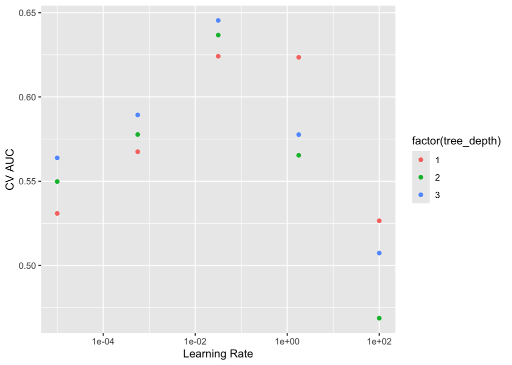

```r
gb_fit |>
  collect_metrics() |>
  print(width = Inf) |>
  filter(.metric == "roc_auc") |>
  ggplot(mapping = aes(x = learn_rate, y = mean, color = factor(tree_depth))) +
  geom_point() +
  labs(x = "Learning Rate", y = "CV AUC") +
  scale_x_log10()
```

```r
gb_fit |>
  show_best("roc_auc")
```

```
# A tibble: 5 × 8
  tree_depth learn_rate .metric .estimator  mean     n  std_err .config
       <int>      <dbl> <chr>   <chr>      <dbl> <int>    <dbl> <chr>
1          3   0.0316   roc_auc binary     0.645     3 0.00275  Preprocessor1_M…
2          2   0.0316   roc_auc binary     0.637     3 0.00154  Preprocessor1_M…
3          1   0.0316   roc_auc binary     0.624     3 0.000848 Preprocessor1_M…
4          1   1.78     roc_auc binary     0.624     3 0.00142  Preprocessor1_M…
5          3   0.000562 roc_auc binary     0.589     3 0.00371  Preprocessor1_M…
```

```r
best_gb <- gb_fit |>
  select_best("roc_auc")
```

```r
final_wf <- gb_wf |>
  finalize_workflow(best_gb)
final_wf
```

```
══ Workflow ════════════════════════════════════════════════════════════════════
Preprocessor: Recipe
Model: boost_tree()

── Preprocessor ────────────────────────────────────────────────────────────────
4 Recipe Steps

• step_impute_mean()
• step_impute_mode()
• step_dummy()
• step_zv()

── Model ───────────────────────────────────────────────────────────────────────
Boosted Tree Model Specification (classification)

Main Arguments:
  trees = 500
  tree_depth = 3
  learn_rate = 0.0316227766016838

Engine-Specific Arguments:
  importance = permutation

Computational engine: xgboost
```

```r
final_fit <-
  final_wf |>
  last_fit(data_split)
```

```r
final_fit |>
  collect_metrics()
```

```
# A tibble: 2 × 4
  .metric  .estimator .estimate .config
  <chr>    <chr>          <dbl> <chr>
1 accuracy binary         0.605 Preprocessor1_Model1
2 roc_auc  binary         0.647 Preprocessor1_Model1
```

```r
saveRDS(gb_grid, file = "gb_grid.rds")
saveRDS(gb_wf, file = "gb_wf.rds")
```

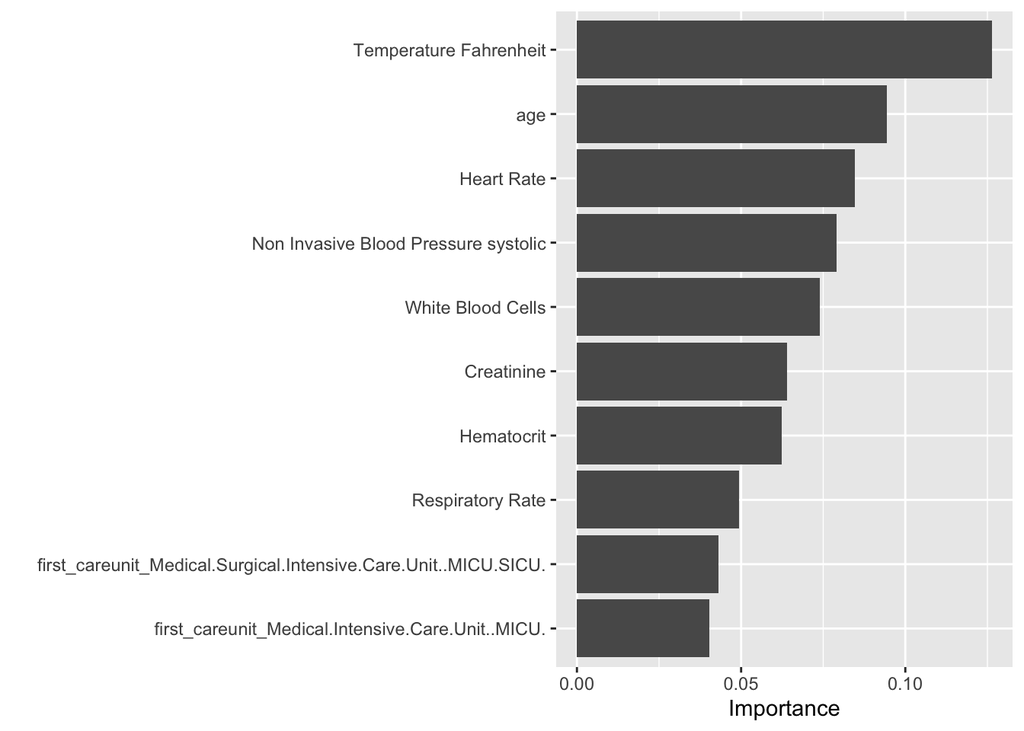

```r
final_fit |>
  extract_fit_parsnip() |>
  vip(num_features = 10)
```